# BAYESIAN INFERENCE FOR DIFFERENCE BETWEEN MEANS

22 Mar 2021 (*updated: 2021-03-22)*

## i. Admin & Startup

## Week 9 Focus

- Midterm 2 (canvas quiz format) was due Friday, 19 Mar 2021, covers mainly Ch.7-10.
- Receive and act on Ch. 9 HW feedback.
- Practice on Ch. 7 content.
- Read Ch. 13. Diff between means .
- Only meet Monday as Wed is “No-Instruction Day”
- Read Ch. 14 Bayes Inference Standard Deviation
- HW 7. Ch.11 #2,5, C5-C7, Ch.12 #4, Ch.13 #1,2,16 due 26 Mar 2021
- All assignments posted for rest of semester.

## HW Ch.9 general feedback

- try knitr options `message=F, warning=F` to avoid unnecessary reporting.
- I think there is some general confusion about updating rules and summarizing the posterior. Let’s review Ch.9,10 updating rules.
- How to compute the posterior median?
- C9-1 was a bit rough for some. How can I help?
- Try to use `rmd` and make a completely reproducible report. Piecewise looks unpolished and hard for me to grade.
- Always include graphs for computer reports. That is the fastest/best way for me to ensure accuracy and for the reader to see the results.

## Midterm 2 feedback

A study using 𝑛=130 Global Positioning System (GPS) sensors near Salt Lake City, UT, finds that 𝑦=31 shifted more than 10 meters in 3 years. Assume that sensors are far enough apart to be independent. Let 𝜋 be the true probability that a GPS sensor moves 10 meters in this geographical area. Use a 𝑏𝑒𝑡𝑎(1,5) prior for 𝜋.

Compute an exact 90% one-sided interval posterior credible interval for the 𝜋, the probability that a GPS sensor has shifted more than 10 meters in 3 years. Report the upper bound to the nearest thousandth place in the box below. Hint: You will first have to find the posterior distribution 𝜋|𝑦.

## Midterm 2 feedback

```
## Posterior Mean           :  0.2352941
## Posterior Variance       :  0.0013134
## Posterior Std. Deviation :  0.0362404
##
## Prob.    Quantile
## ------   ---------
## 0.005    0.1498296
## 0.010    0.1570988
## 0.025    0.1681315
## 0.050    0.1779549
## 0.500    0.2339936
## 0.950    0.2970741
## 0.975    0.3098273
## 0.990    0.3248849
## 0.995    0.3352680
```

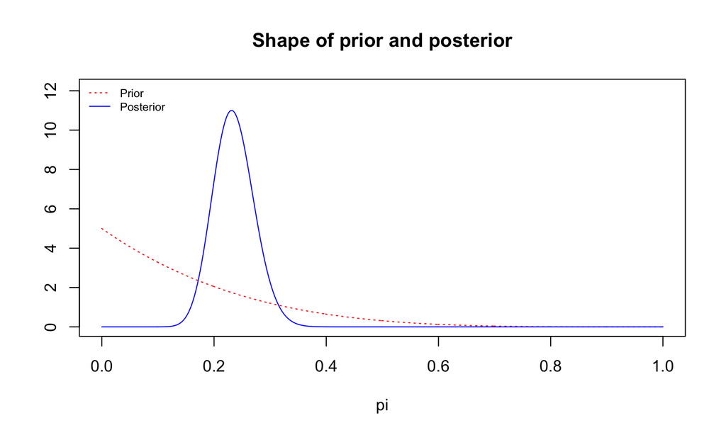

```r
fit  <- binobp( x = 31, n = 130, a = 1, b = 5, plot = F)
```

```r
quantile( fit, probs = 0.9 )
```

```
## [1] 0.2826155
```

## Today’s plan

- Prime by discussion via HW 7, ch. 13 exercise prompts.
- Discuss Ch. 13.
- Summarize, Revisit HW or Q & A

*Please contribute questions and comments*

## I. Preview Problem Set 7, Ch. 13

- Ch.13 #1,2,16

## II. Ch.13 Bayesian Inference for Difference between Means

- Often the core scientific question is whether a parameter is different between two groups
- Such as: patients who took Drug A vs Drug B, online class vs. traditional, etc.
- This chapter discusses Bayesian inference for a difference of means, using normal modeling.

## Ch. 13.1 Independent Random Samples from Two Normal Distributions

## Email data for UG vs Grad

*Email data was generating through informal survey*:

1. Think carefully about how many times a work day you check email in a 24-hour period.
2. Enter your guess in the chat (only once please for collection purposes) and state your student status (Grad or UG).
3. We’ll analyze these data to assess the statistical evidence whether graduate and undergraduate students check email a different number of times, on average.

## Email data for UG vs Grad

Construct the posterior distribution for each group, assumming independent random samples from two normal distributions and known standard deviation of 3.

```r
## SP20 data. may be interesting to retain/compare
y_u <- c(3, 3, 5, 4, 4, 10, 4, 5, 8, 5, 5, 10, 4, 15, 5)
y_g <- c(4, 5, 10, 4, 5)
n_u <- length(y_u)
n_g <- length(y_g)

## For simplicity, assume the same priors for each group
## prior mean
m <- 5
## prior variance
s2 <- 10^2
## Assuming equal, known variance!
sigma2 <- 3^2
```

## Email data for UG vs Grad

```r
## Compute the posterior for each sample
compute_normalMean_normalPrior <- function(m, s2, n, y_bar, sigma2){
    ## posterior precision is the sum of prior and sample precision
    total_precision <- 1/s2 + n/sigma2
    s_prime2 <- 1/total_precision
    ## posterior mean is the weighted average of prior and sample mean
    m_prime <- ( (1/s2) / total_precision ) * m + ( (n/sigma2) / total_precision ) * y_bar
    ## return as a list
    list(m_prime=m_prime, s_prime2=s_prime2, s_prime = sqrt(s_prime2))
}
```

## Email data for UG vs Grad

```r
(mu_u_post <- compute_normalMean_normalPrior(m = m, s2 = s2, n =  n_u, y_bar = mean(y_u), sigma2 = sigma2))
```

```
## $m_prime
## [1] 5.994036
##
## $s_prime2
## [1] 0.5964215
##
## $s_prime
## [1] 0.7722833
```

```r
(mu_g_post <- compute_normalMean_normalPrior(m = m, s2 = s2, n =  n_g, y_bar = mean(y_g), sigma2 = sigma2))
```

```
## $m_prime
## [1] 5.589391
##
## $s_prime2
## [1] 1.768173
##
## $s_prime
## [1] 1.329727
```

## Case 1. 13.2 Inference with equal variances

- This is a sensible model for experimental data in a completely randomized design. Why?
- Let’s discuss what is meant by an “additive” model.
- The methods is this chapter instruct how to conduct Bayesian inference for the difference in means \(\mu_d = \mu_1 - \mu_2\).
- Recall how this was done using classical statistics. We had to make assumptions on distributions (or appeal to CLT) and variances. Then we conduct a \(t-\)test.

## Email data for UG vs Grad, equal variances

Using the results from the previous section, find a 95% credible interval the mean difference.

```r
## First find the posterior for the difference in means.
## Since the samples were independent this is easily to compute.
mu_d_mean <- mu_g_post$m_prime - mu_u_post$m_prime
mu_d_stderror <- sqrt(mu_g_post$s_prime2 + mu_u_post$s_prime2)

## Difference of normal rvs is also normal
## Here is a 95% credible interval for mu_d
c(mu_d_mean - qnorm(0.975) * mu_d_stderror, mu_d_mean + qnorm(0.975) * mu_d_stderror)
```

```
## [1] -3.418528  2.609238
```

```r
## 1-sided credible interval (upper bound)
z_star <- qnorm(0.950)
mu_d_mean + z_star * mu_d_stderror
```

```
## [1] 2.124686
```

## Email data for UG vs Grad, equal variances

Now test the hypotheses that

\(H_0: \mu_d \leq 0\) versus \(H_0: \mu_d > 0\).

```r
## one sided hypothesis test
pnorm(0, mean = mu_d_mean, sd = mu_d_stderror)
```

```
## [1] 0.6037807
```

```r
## z score (to use a table)
pnorm((0 - mu_d_mean) / mu_d_stderror)
```

```
## [1] 0.6037807
```

## Email data for UG vs Grad, equal variances

And the two-sided test

\(H_0: \mu_d = 0\) versus \(H_0: \mu_d \neq 0\).

```r
## We do
alpha = 0.1
z_star = qnorm( 1 - alpha /2 )
c(mu_d_mean -  z_star * mu_d_stderror, mu_d_mean + z_star * mu_d_stderror)
```

```
## [1] -2.933975  2.124686
```

## Email data for UG vs Grad, unknown, equal variances

Repeat above, but assume unknown (but equal) variance with flat priors

Use \(t(n_u + n_g - 2)\) and Equation 13.7. Pool together the samples to estimate the variances since the variances are the same for the two groups.

## Email data for UG vs Grad, unequal variances

- Discuss using textbook (nonadditive).
- Compute the posterior parameters under independent sampling and priors. The updating rules are exactly the same.
- For a credible interval with normal priors use Equation 13.9 (same as 13.2).
- For a credible interval with flat priors (coinciding with the frequentist confidence interval) use Equation 13.10.

Normal prior credible interval with known, unequal variances:

For our email data, compute a 90% credible interval using the priors from before and assume that \(\sigma_u = 10\) and \(\sigma_g = 5\).

## Email data for UG vs Grad, unknown, unequal variances

Use Satterthwaite’s approximation for the degrees of freedom on page 263.

```r
## The (unbiased) variance estimators given by Bolstad & Curran are built into R
1 / ( length(y_g) - 1 ) * sum( (y_g - mean(y_g) )^2 )
```

```
## [1] 6.3
```

```r
var(y_g)
```

```
## [1] 6.3
```

## III. 13.5 Paired (dependent) samples

*Email data was generating through informal survey*:

1. Think about how many times you check your email on a regular workday day versus a COVID-19 workday.
2. Let’s disregard the graduate/undergraduate aspect for this analysis.
3. Enter your difference (COVID-19 num of email checks) - (Regular workday) into the chat please.

## Email data, COVID behavior change

```r
diff_in_email <- c(-2, 0, -1, -3, 5, 1, 2 , 5, 0, 4, 5, 0, 4, 2 ,6 ,10, 8)
length(diff_in_email)
```

```
## [1] 17
```

```r
summary(diff_in_email)
```

| Min. | 1st Qu. | Median | Mean | 3rd Qu. | Max. |
| --- | --- | --- | --- | --- | --- |
| -3 | 0 | 2 | 2.705882 | 5 | 10 |

## Email data, COVID behavior change

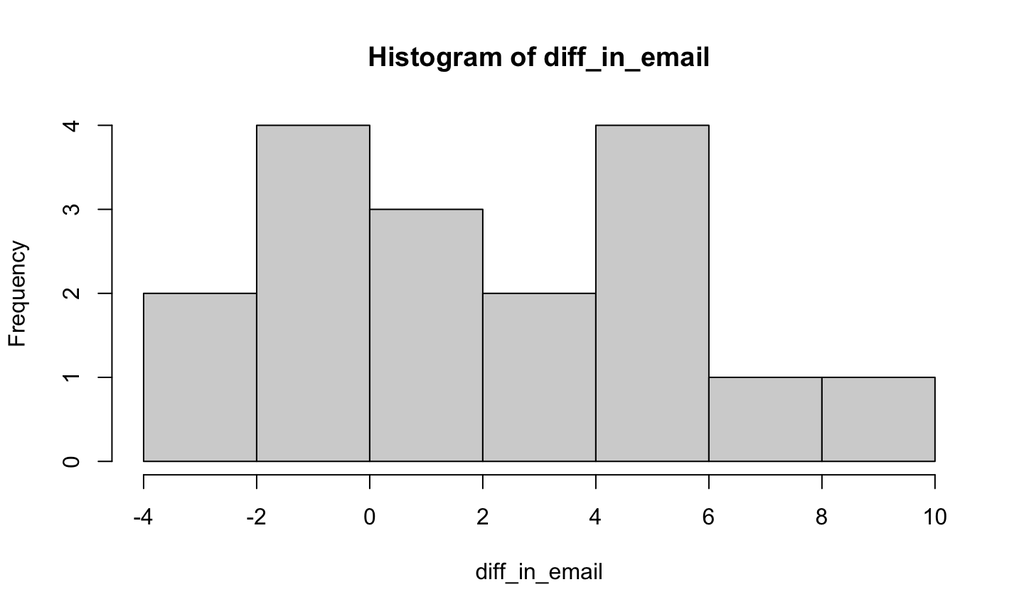

```r
hist(diff_in_email)
```

## Email data, COVID behavior change

```r
## Skeptical, Weakly Informative Prior (WIP)
m = 0
s2 = 20^2
## Treat these (differenced data) a sample from a single normal population with unknown variance
(post_param <- compute_normalMean_normalPrior(m = m, s2 = s2, n = length(diff_in_email), y_bar = mean(diff_in_email), sigma2 = var(diff_in_email)))
```

```
## $m_prime
## [1] 2.70078
##
## $s_prime2
## [1] 0.7541981
##
## $s_prime
## [1] 0.8684458
```

## Email data, COVID behavior change

Construct a 95% credible interval.

```r
n <- length(diff_in_email)
## critical value
alpha <- 0.05
t_star <- qt(p = 1 - alpha / 2, df = n - 1)
## two-sided interval
c( post_param$m_prime - ( t_star * post_param$s_prime ) ,
  post_param$m_prime + (  t_star * post_param$s_prime ) )
```

```
## [1] 0.8597576 4.5418033
```

## Email data, COVID behavior change

```r
## 1-sided
t_star <- qt(p = 1 - alpha, df = n - 1)
post_param$m_prime - ( t_star * post_param$s_prime ) ## lower bound 1-sided
```

```
## [1] 1.184575
```

```r
post_param$m_prime + ( t_star * post_param$s_prime ) ## upper bound 1-sided
```

```
## [1] 4.216986
```

## Email data, COVID behavior change

Under a flat prior

```r
## Flat improper prior for the mean has infinite variance
(post_param <- compute_normalMean_normalPrior(m = 0, s2 = Inf, n = length(diff_in_email), y_bar = mean(diff_in_email), sigma2 = var(diff_in_email)))
```

```
## $m_prime
## [1] 2.705882
##
## $s_prime2
## [1] 0.7556228
##
## $s_prime
## [1] 0.8692657
```

## Email data, COVID behavior change

Under a flat prior, agrees with Frequentist \(t-\)test.

```r
t_star <- qt(p = 1 - alpha / 2, df = n - 1)
## two-sided interval
c( post_param$m_prime - ( t_star * post_param$s_prime ) , post_param$m_prime + (  t_star * post_param$s_prime ) )
```

```
## [1] 0.8631214 4.5486433
```

```r
t.test(x = diff_in_email, conf.level = 0.95) ## or  just compute the frequentist version
```

```
##
##  One Sample t-test
##
## data:  diff_in_email
## t = 3.1128, df = 16, p-value = 0.006697
## alternative hypothesis: true mean is not equal to 0
## 95 percent confidence interval:
##  0.8631214 4.5486433
## sample estimates:
## mean of x
##  2.705882
```

## IV. Closing

Reply in the chat:

- How to know which difference formula to use from Ch.13?
- Discuss shortcomings of the survey-based data collection from today’s meeting. Do you expect the estimates to be biased?